# Data Product Pitch

7/1/2020

## Introduction

This pitch deck describes the Shiny application: MTCars Linear Model Creation Kit. Its purpose is for visual EDA of fitting linear models on the MtCars dataset.

The tool has the following components.

- **Control panel**: controls the number of features fit and the target feature, also toggles displays
- **Density Plot of Fitted Residuals**: shows the density of fitted residuals over all fitted models
- **Line Graph of Mean Squared Error**: shows MSE over all fitted models indexed by number of features fit, as well as the average and minimum MSEs.
- **Table**: shows the linear model formula and its corresponding MSE.

In the backend, the program iteratively fits the linear model with the feature resulting in a minimum Mean Squared Error and stores the models, formulae, and MSE internally.

**Predictor Selector**: Allows user to select any of the features provided in mtcars, they are the following.

```
##  [1] "mpg"  "cyl"  "disp" "hp"   "drat" "wt"   "qsec" "vs"   "am"   "gear"
## [11] "carb"
```

**Feature Selector**: Allows user to select a range of features, between 1 and 10. If only one feature is selected, then only one feature will be displayed.

**Toggle Checkboxes**: Allows user to toggle the individual visuals on and off, quite self explanatory.

## Density Plot

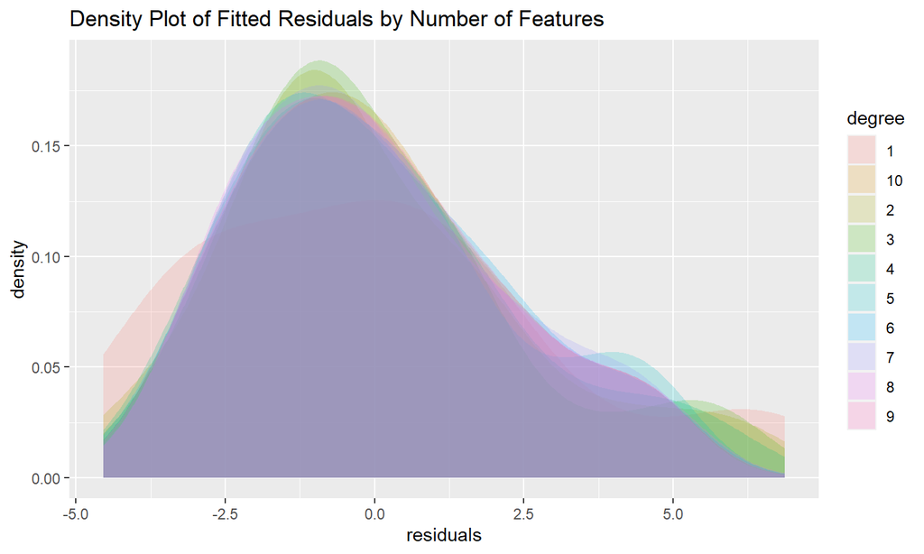

## MSE Line Graph

- It plots the MSE for each fit model, as well as its average and minimum.
- The purpose of this plot is to show how MSE reduces as more features are fit and ultimately to serve as a hockeystick analysis for selecting the number of features.

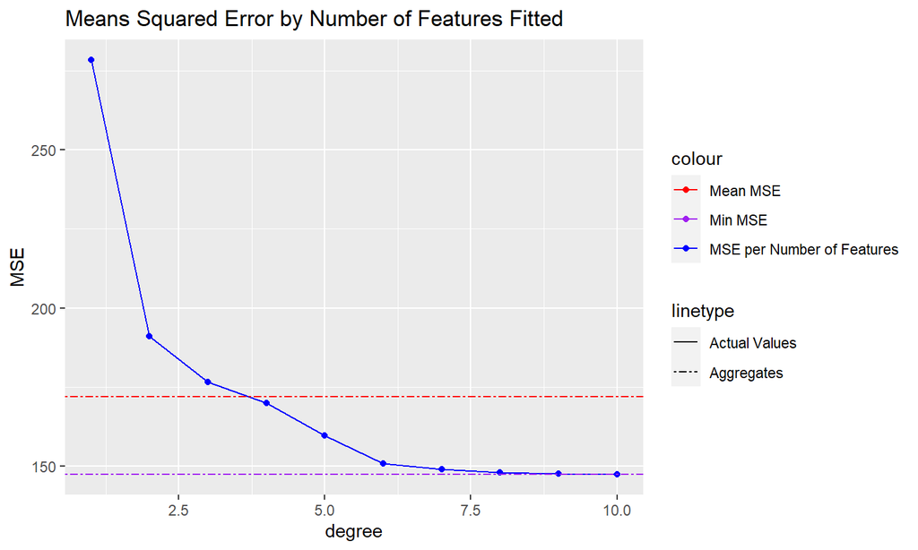